# Model_Test

## Reading in the data

```python
import numpy as np
import pandas as pd
import matplotlib.pyplot as plt

import json
import time

from sklearn.model_selection import train_test_split
from sklearn.decomposition import PCA
from sklearn.preprocessing import StandardScaler
from sklearn.preprocessing import LabelEncoder
from sklearn.preprocessing import OneHotEncoder
from sklearn.linear_model import LogisticRegressionCV
from sklearn.ensemble import RandomForestClassifier

np.random.seed(21)
```

```python
# data = pd.read_csv('single_slice_audio_features copy.csv')
# data = pd.read_csv("single_slice_augmented_features.csv", encoding='latin1')
data = pd.read_csv("single_slice_k_means.csv", index_col=0)
```

```python
import warnings
warnings.filterwarnings('ignore')

cols = list(data.columns[8:])
cols.append('duration_ms')

# get rid of NaNs unless they make up more than 5% of the data
na_idxs = data[data[cols].isna().any(axis=1)].index
assert len(na_idxs) < 0.05*len(data)
data = data.drop(na_idxs).reset_index(drop=True)

df = data[cols]

# change release date to decade
df['release_decade'] = df['release_dates'] // 10 # turn years into decades
df = df.drop('release_dates', axis=1)

display(df.head())
print()
display(df.columns)
```

|  | track_uri | playlist_id | acousticness | danceability | energy | instrumentalness | key | liveness | loudness | mode | speechiness | tempo | time_signature | valence | explicit | 4_means_cluster | duration_ms | release_decade |
| --- | --- | --- | --- | --- | --- | --- | --- | --- | --- | --- | --- | --- | --- | --- | --- | --- | --- | --- |
| 0 | spotify:track:2g8HN35AnVGIk7B8yMucww | 49000 | 0.43200 | 0.778 | 0.578 | 0.000000 | 9.0 | 0.1380 | -7.220 | 0.0 | 0.2740 | 84.487 | 4.0 | 0.758 | 1 | 0 | 252746 | 199 |
| 1 | spotify:track:4OhkKmvhjl3yk7JF422GWB | 49000 | 0.20100 | 0.900 | 0.632 | 0.001630 | 4.0 | 0.0676 | -6.183 | 0.0 | 0.2770 | 94.062 | 4.0 | 0.875 | 0 | 0 | 236733 | 199 |
| 2 | spotify:track:1NHwvBmrUje4L1dxfWnXCH | 49000 | 0.00864 | 0.906 | 0.623 | 0.000004 | 1.0 | 0.0753 | -6.711 | 0.0 | 0.3030 | 99.498 | 4.0 | 0.715 | 1 | 0 | 194293 | 199 |
| 3 | spotify:track:1EM23A621Z0QyTlWKu7T1l | 49000 | 0.10200 | 0.928 | 0.771 | 0.000011 | 3.0 | 0.3380 | -5.935 | 0.0 | 0.2510 | 93.987 | 4.0 | 0.679 | 1 | 0 | 231160 | 199 |
| 4 | spotify:track:6uQKuonTU8VKBz5SHZuQXD | 49000 | 0.01590 | 0.799 | 0.630 | 0.000000 | 0.0 | 0.4530 | -9.279 | 1.0 | 0.0748 | 103.647 | 4.0 | 0.772 | 0 | 2 | 238800 | 199 |

```
Index(['track_uri', 'playlist_id', 'acousticness', 'danceability', 'energy',
       'instrumentalness', 'key', 'liveness', 'loudness', 'mode',
       'speechiness', 'tempo', 'time_signature', 'valence', 'explicit',
       '4_means_cluster', 'duration_ms', 'release_decade'],
      dtype='object')
```

The above output shows the head of the DataFrame with data for each song as obtained from Spotify's API. There is also a list of columns for the reader to understand the various predictors used.

The below cell contains a separation of the predictors into numerical and categorical predictors, with columns such as `track_uri` and `playlist_id` which will not directly be used in the training of the model in the `X_labels_other` group.

```python
X_labels_num = ['acousticness', 'danceability', 'energy', 'instrumentalness',
                'liveness', 'loudness', 'speechiness', 'tempo', 'valence',
                'duration_ms']
X_labels_cat = ['key', 'mode', 'time_signature', 'release_decade', 'explicit', '4_means_cluster']
X_labels_other = df.columns.drop(X_labels_num).drop(X_labels_cat)
```

The next step is to transform the data. Standardization is perfomred on the numerical predictors in order to prepare them for Principal Component Analysis. Additionally, the categorical predictors are one-hot-encoded.

```python
def transform_data(X, num_labels=X_labels_num, cat_labels=X_labels_cat):
  """
  Function to transform the data i.e. one-hot encode the categorical variables
    and standardize (𝜇=0, 𝜎=1) the numerical variables.
  """
  scaler = StandardScaler()
  ohe = OneHotEncoder()
  X_num = pd.DataFrame(scaler.fit_transform(X[num_labels]), columns=num_labels).reset_index(drop=True)
  X_cat = pd.get_dummies(X[cat_labels].astype(object)).reset_index(drop=True)
  X_out = X_cat
  X_out[num_labels] = X_num
  X_out[X_labels_other] = X[X_labels_other].reset_index(drop=True)
  return X_out
```

```python
df_scaled = transform_data(df)
```

## Helper Functions

```python
def separate_target_playlist(playlist_id, n_pca_comps = None):
  """
  Separates the overall `df_scaled` into a target playlist (`playlist1`) and
    the rest of the unique songs in the dataset of playlists (`rest`).
  """
  if n_pca_comps is None:
    this_df = df_scaled.copy()
  else:
    pca = PCA(n_pca_comps)
    df_pca = pd.DataFrame(pca.fit_transform(df_scaled[labels]))
    df_pca[["track_uri", "playlist_id"]] = df_scaled[["track_uri", "playlist_id"]]
    this_df = df_pca

  playlist1 = this_df[this_df['playlist_id'] == playlist_id].reset_index(drop=True)
  rest = this_df[this_df['playlist_id'] != playlist_id].drop_duplicates("track_uri")
  return playlist1, rest

def get_X_train_test(test_size=0.3, random_state=None):
  """
  Gets the train and test data subsets.
  """
  X_train_1, X_test_1 = train_test_split(playlist1, test_size=test_size, random_state=random_state)
  X_train = X_train_1.append(rest.sample(n=len(X_train_1), random_state=random_state))
  X_test = X_test_1.append(rest.sample(n=len(X_test_1), random_state=random_state))
  y_train = (X_train['playlist_id'] == playlist_id).astype(int)
  y_test = (X_test['playlist_id'] == playlist_id).astype(int)
  X_train.drop(['playlist_id'], axis=1, inplace=True)
  X_test.drop(['playlist_id'], axis=1, inplace=True)

  return X_train, X_test, y_train, y_test
```

We know which songs the user already wants in the playlist. However, we don't know what songs they would not want to put in the playlist. So, we decided to randomly sample the `rest` dataset for a sample of equal size to the target playlist and assume that the user rejected those songs from the playlist. Because there are many songs in this dataset, this should be a reasonable assumption.

[figure not shown]

The above figure illustrates how the training set and test sets are chosen. The striped blocks represent test set selections (in reality, the test set is randomly sampled from Playlist 1) and the solid blocks are the training set. Green means the user wants that song in the playlist, while red is our assumption that the person would not want that song in the playlist.

```python
def get_probs(data, n_estimators=100, max_depth=10):
  """
  data = which playlist dataset you want to predict (`rest` or `playlist1`)

  Returns the predicted probabilities for songs in data
  """
  model = RandomForestClassifier(n_estimators=n_estimators, max_depth=max_depth)
  model.fit(X_train[labels], y_train)
  train_accs.append(model.score(X_train[labels], y_train))
  test_accs.append(model.score(X_test[labels], y_test))
  return model.predict_proba(data[labels])[:,1]
```

The `get_probs` function takes in a playlist dataset with all relevant predictors and returns an array of the predicted probabilities that each song is in the playlist. First, a Random Forest Classifier is trained on the training set. Next, the train and test accuracies are added to lists. The function returns a list of the probabilities that each song in the passed in `data` is assigned by the model as being classified into the playlist. We are operating under the assumption that the predicted probabilities are analogous to the probability that a user would add the song to the playlist.

Using the above methodology could be prone to some missteps, however. There is a nonzero chance that the randomized selection of songs that are classified as 0's could include a song that the user would actually want in the playlist:

[figure not shown]

The red point in the cluster of green could occur. Additionally, this method of randomly sampling the rejected songs could lead to the model being overfit to the one randomly selected sample of songs as the rejected playlist. In order to combat this, we propose a model we are calling the *Bagged Forest*.

## Bagged Forest

The bagging in "Bagged Forest" comes from the ensemble method of Bootstrap AGGregatING. Instead of bootstrapping a subset of the training set to train many weak learners, we are bootstrapping the rejected songs from the playlist in order to reduce the bias while also reducing variance due to the Central Limit Theorem. Bootstrapping provides a different rejected set for each training dataset. Then, the resulting probabilities from each iteration of the bootstrap are averaged in order to obtain final probability predictions for the Bagged Forest model:

[figure not shown]

```python
# store the train and test accuracies from each Random Forest model
train_accs = []
test_accs = []
```

```python
def bootstrap_0s(this_playlist_id, include_k_means=True, n_iter=1000,
                 random=True, n_estimators=50, n_pca_comps = None,
                 max_depth=15, print_progress=False):
  """
  this_playlist_id = desired playlist_id to match
  include_k_means = boolean of whether to include the $k$-means predictor
  n_iter = number of iterations of the bootstrapped selection of songs
    to not include in the playlist; default 1000
  random = whether or not the bootstrap should be random
  n_estimators = number of estimators in Random Forest
  n_pca_comps = number of PCA components desired. Value of None means no PCA
    will be performed
  max_depth = max depth of trees in Random Forest
  print_progress = boolean of whether to print when each iteration is done
    being fitted (to track progres)

  Function returns mean probability for each song in `rest`, `playlist1` over
    bootstrap (2 return items) and times the duration.
  """
  start = time.time()

  # save playlist_id as global variable
  global playlist_id, labels
  playlist_id = this_playlist_id

  # get labels
  labels = df_scaled.columns.drop(["track_uri", "playlist_id"])

  # if not including k_means, drop columns associated with k-means clusters
  if not include_k_means:
    for col in df_scaled.columns:
      if "means_cluster" in col:
        labels = labels.drop([col])

  # get target playlist and rest
  global playlist1, rest
  playlist1, rest = separate_target_playlist(playlist_id, n_pca_comps = n_pca_comps)

  # get labels (have to run get_X_train_test once)
  global X_train, X_test, y_train, y_test
  X_train, X_test, y_train, y_test = get_X_train_test(random_state=0)
  labels = X_train.columns.drop('track_uri')

  # set random state to None if user wants randomness
  if random:
      random_state=None

  # create list to store probability predictions
  playlist1_prob_preds = []
  rest_prob_preds = []

  # begin iterations
  for i in range(n_iter):
    if print_progress:
      j = 0
      if i % (n_iter // 20) is 0:
        print(j, ' ', sep='')
        j += 5
    if not random:
      random_state=i
    X_train, X_test, y_train, y_test = get_X_train_test(random_state=random_state)
    rest_prob_preds.append(get_probs(rest, n_estimators=n_estimators, max_depth=max_depth))
    playlist1_prob_preds.append(get_probs(playlist1, n_estimators=n_estimators, max_depth=max_depth))

  # aggregate probability predicts with mean
  rest_prob_preds = np.array(rest_prob_preds)
  playlist1_prob_preds = np.array(playlist1_prob_preds)

  end = time.time()
  print("Elapsed Time:", end - start)

  return np.mean(rest_prob_preds, axis=0), np.mean(playlist1_prob_preds, axis=0)
```

```python
def get_results(n_predictions=10, diagnostics = False):
  """
  Diagnostics include plots of accuracies and predictions, mean prediction
    probability in the target playlist, and worst-performing songs in the
    training playlist

  diagnostics=False returns only the top n_predictions and the accuracy of the
    on the Bagged Forest on the target playlist
  """
  acc = np.mean(playlist1_prob_preds >= 0.5)
  print("Bagged Forest accuracy for songs in Target Playlist:")
  print(acc)
  print()

  if diagnostics:
    print("Mean Prediction Probability for Target Playlist:")
    print(np.mean(playlist1_prob_preds))
    print()

  rest['prob_in_playlist'] = rest_prob_preds
  results = rest.sort_values('prob_in_playlist', ascending=False)
  track_uris = list(playlist1['track_uri'])

  # get rest tracks that are not in playlist1
  exclusive_results = results[~results['track_uri'].isin(track_uris)]
  clean_results = data.loc[list(exclusive_results.index)][['artist_name','track_name']]
  clean_results['prob_in_playlist'] = exclusive_results['prob_in_playlist']
  print("Top Predictions")
  display(clean_results.head(n_predictions))

  if diagnostics:
    # get plots
    fig, axs = plt.subplots(2,2,figsize=(12,7))

    axs.flat[0].hist(playlist1_prob_preds, color="C0")
    axs.flat[0].set_title('Predicted Probabilities for Each Song in Target Playlist', size=14)
    axs.flat[0].axvline(0.5, color="red")
    axs.flat[0].set_xlabel("Song's Predicted Probability", size=12)

    axs.flat[1].hist(rest_prob_preds, color="C0")
    axs.flat[1].set_title('Distribution of Predicted Probabilities for All Songs', size=14)
    axs.flat[1].set_xlabel("Song's Predicted Probability", size=12)
    axs.flat[1].axvline(0.5, color="red")

    axs.flat[2].hist(train_accs, color="C2")
    axs.flat[2].set_title("Train Set Accuracy Distribution for Each Iteration", size=14)
    axs.flat[2].set_xlabel("Train Accuracy", size=12)

    axs.flat[3].hist(test_accs, color="C2")
    axs.flat[3].set_title("Test Set Accuracy Distribution for Each Iteration", size=14)
    axs.flat[3].set_xlabel("Test Accuracy", size=12)

    plt.tight_layout()
    plt.show()

    # get worst playlist1 tracks
    playlist1['prob_in_playlist'] = playlist1_prob_preds
    results = playlist1.sort_values('prob_in_playlist', ascending=True)
    self_results = data.loc[list(results.index)][['artist_name','track_name']]
    self_results['prob_in_playlist'] = results['prob_in_playlist']
    print()
    print("Worst-Performing Songs on Target Playlist")
    display(self_results.head(10))
```

```python
# rest_prob_preds, playlist1_prob_preds = bootstrap_0s(49001, n_pca_comps=5, include_k_means=False, n_iter=40)
rest_prob_preds, playlist1_prob_preds = bootstrap_0s(49002, n_iter=40)
```

```
Elapsed Time: 12.59311318397522
```

```
Bagged Forest accuracy for songs in Target Playlist:
1.0

Mean Prediction Probability for Target Playlist:
0.7957834647260967

Top Predictions
```

|  | artist_name | track_name | prob_in_playlist |
| --- | --- | --- | --- |
| 18641 | Matt Corby | Made Of Stone | 0.933333 |
| 36668 | Sleeping At Last | 101010 | 0.930000 |
| 44040 | RKCB | Baptize | 0.926000 |
| 7128 | James Blake | Retrograde | 0.922000 |
| 28738 | Of Monsters and Men | Love Love Love | 0.921500 |
| 7154 | London Grammar | Wasting My Young Years | 0.920000 |
| 376 | Lana Del Rey | Salvatore | 0.917333 |
| 40247 | Sam Smith | Lay Me Down | 0.914500 |
| 4378 | King Krule | Baby Blue | 0.913000 |
| 42082 | Shoffy | Goodnight | 0.913000 |

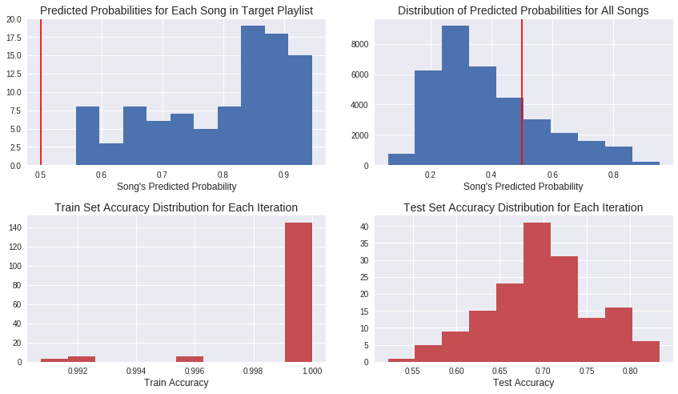

```
Worst-Performing Songs on Target Playlist
```

|  | artist_name | track_name | prob_in_playlist |
| --- | --- | --- | --- |
| 55 | Dr. Dre | The Next Episode | 0.557971 |
| 75 | P.M. Dawn | Set Adrift on Memory Bliss (Re-Recorded) | 0.563667 |
| 6 | R. Kelly | Bump n' Grind | 0.565471 |
| 76 | Fatman Scoop | Be Faithful | 0.565500 |
| 7 | Eazy-E | Boyz-N-The-Hood | 0.566471 |
| 83 | En Vogue | Free Your Mind | 0.587000 |
| 36 | Destiny's Child | Say My Name | 0.589392 |
| 12 | Mark Morrison | Return Of The Mack - C & J Street Mix | 0.589500 |
| 41 | 2Pac | California Love - Original Version | 0.600471 |
| 45 | Warren G | Regulate | 0.625000 |

```python
get_results(diagnostics=True)
```

# PCA Playground

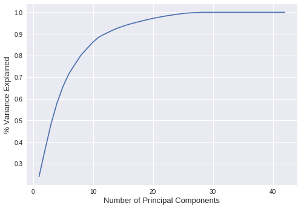

```python
pca = PCA(len(labels))
pca.fit(X_train[labels])
plt.plot(range(1,len(labels)+1), np.cumsum(pca.explained_variance_ratio_))
plt.xlabel("Number of Principal Components", size=13)
plt.ylabel("% Variance Explained", size=13)

plt.show()
```

I'll choose 10 principal components to a reasonable amount of variance explained. I'm worried if I choose fewer, then the data will be too dense

# Todo

## Bootstrap the 0's in the training set in order to make it more robust.

## Tune `n_predictors` and `n_iterations` in Random Forest

```python
data[data['track_uri'] == "spotify:track:3JkDhCmTQqMe2MJli79ZEz"]
```

|  | Unnamed: 0 | album_name | album_uri | artist_name | artist_uri | duration_ms | pos | track_name | track_uri | playlist_id | ... | energy | instrumentalness | key | liveness | loudness | mode | speechiness | tempo | time_signature | valence |
| --- | --- | --- | --- | --- | --- | --- | --- | --- | --- | --- | --- | --- | --- | --- | --- | --- | --- | --- | --- | --- | --- |
| 36007 | 36007 | Piano And Cello Duet | spotify:album:700HZzIbdxG1xf2ucB2Si8 | Brian Crain | spotify:artist:6roo9MjIl9htSsX2Snnipb | 244960 | 5 | Song For Sienna | spotify:track:3JkDhCmTQqMe2MJli79ZEz | 49530 | ... | 0.226 | 0.872 | 7.0 | 0.106 | -14.709 | 1.0 | 0.0347 | 88.371 | 3.0 | 0.158 |

1 rows × 22 columns

```python
data.loc[35838]
```

```
Unnamed: 0                                          35838
album_name          Home Alone - 25th Anniversary Edition
album_uri            spotify:album:3rDo7fQDUwJ6qmxwP5yQsY
artist_name                                 John Williams
artist_uri          spotify:artist:3dRfiJ2650SZu6GbydcHNb
duration_ms                                        147173
pos                                                    73
track_name                       The House - Instrumental
track_uri            spotify:track:6dmUz77mDLsUhkoYu9c4rO
playlist_id                                         49526
acousticness                                        0.943
danceability                                        0.336
energy                                             0.0498
instrumentalness                                    0.635
key                                                     2
liveness                                           0.0915
loudness                                          -24.453
mode                                                    0
speechiness                                        0.0289
tempo                                              97.306
time_signature                                          4
valence                                             0.101
Name: 35838, dtype: object
```